# White wine properties and quality by M. Joukamaa

In this report I am examining a dataset on white wine samples. The dataset contains measurements about several chemical and physical qualities of the samples as well as ratings given to them by wine-tasting experts.

# Univariate Plots Section

As a first step of the examination, I am creating univariate plots and numerical summaries of all the different variables present in the data. In these initial examinations I am considering mostly the values from the lowest one of each variable up to the 0.75 quantile of the value range. The reason for this is that even the most cursory overview of the histograms and the value summaries below shows that the maximum values are not particularly representative of the distributions in most of the cases.

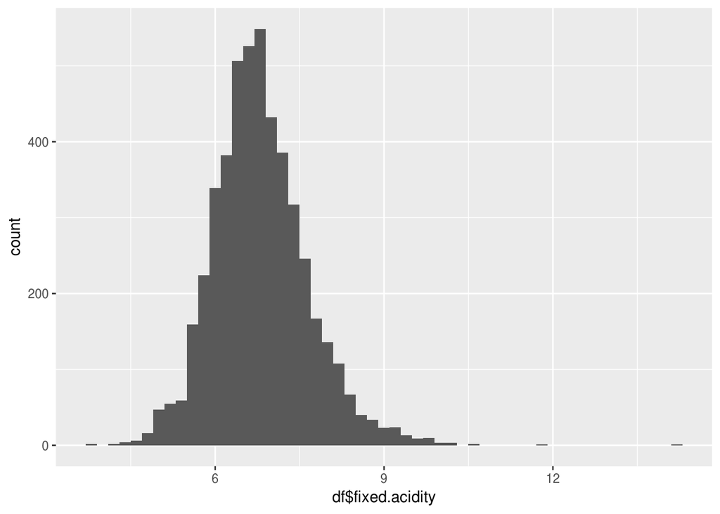

```
##    Min. 1st Qu.  Median    Mean 3rd Qu.    Max.
##   3.800   6.300   6.800   6.855   7.300  14.200
```

Fixed acidity ranges in 75 % of the samples from 3.8 grams per cubic decimetre to 7.3 grams per cubic decimetre with a median of 6.8 grams per cubic decimetre.

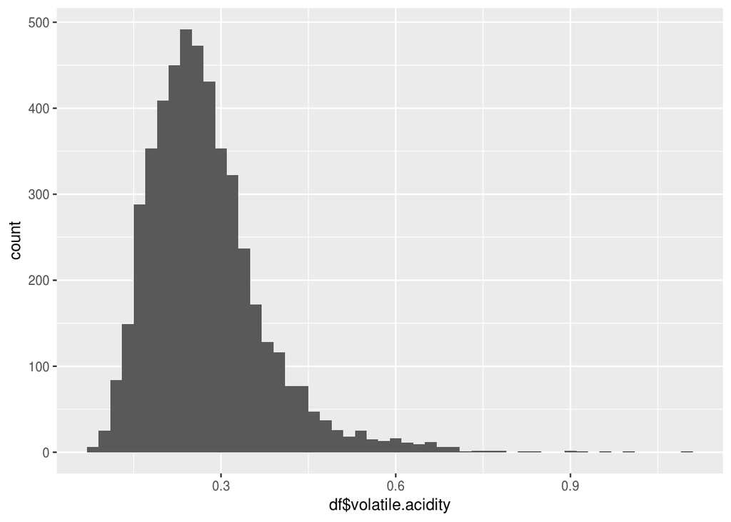

```
##    Min. 1st Qu.  Median    Mean 3rd Qu.    Max.
##  0.0800  0.2100  0.2600  0.2782  0.3200  1.1000
```

Volatile acidity ranges from 0.08 grams per cubic decimeter to 0.32 grams per cubic decimeter for 75 % of the samples with a median of 0.26 grams per cubic decimetre.

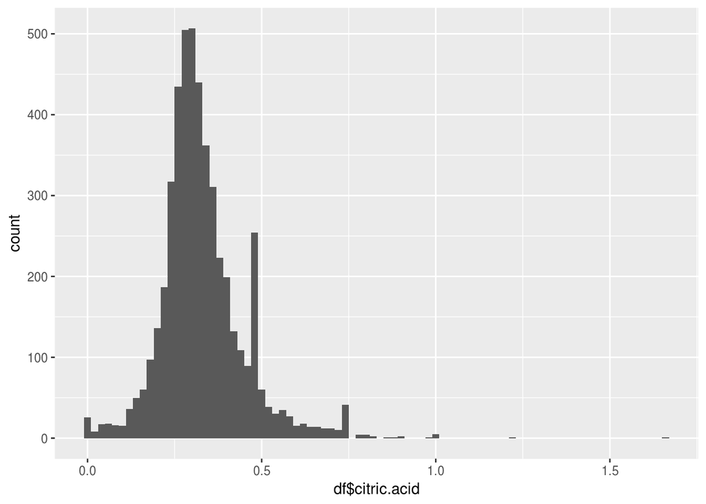

```
##    Min. 1st Qu.  Median    Mean 3rd Qu.    Max.
##  0.0000  0.2700  0.3200  0.3342  0.3900  1.6600
```

Citric acid concentrations range in 75 % of the samples from round zero to 0.39 grams per cubic decimetre with a median of 0.32 grams per cubic decimetre. There is also a noticeable spike of samples for citric acid concentrations of slightly below 0.5 grams per cubic decimetre.

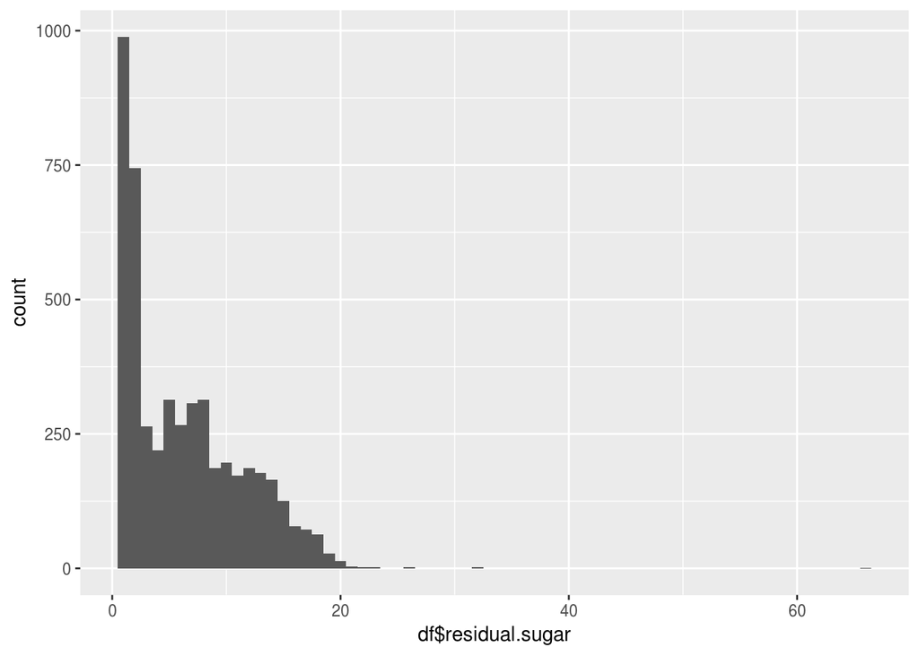

```
##    Min. 1st Qu.  Median    Mean 3rd Qu.    Max.
##   0.600   1.700   5.200   6.391   9.900  65.800
```

The quantities of residual sugar in the samples range from 0.6 grams per cubic decimetre to 9.9 grams per cubic decimetre for 75 % of them with a median of 5.2 grams per cubic decimetre. Compared to the previous chemical and physical sample properties plotted, the distribution skews more notably to the right and is especially concentrated on the lower end of the values.

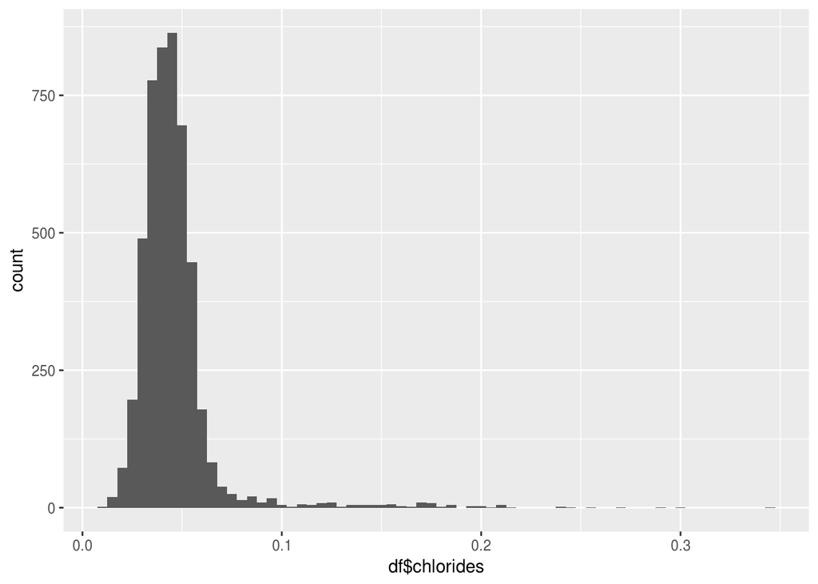

```
##    Min. 1st Qu.  Median    Mean 3rd Qu.    Max.
## 0.00900 0.03600 0.04300 0.04577 0.05000 0.34600
```

The amount of chlorides (essentially, salt) present ranges from 0.009 grams per cubic decimeter to 0.05 grams per cubic decimeter for 75 % of the samples with a median of 0.043 grams per cubic decimetre.

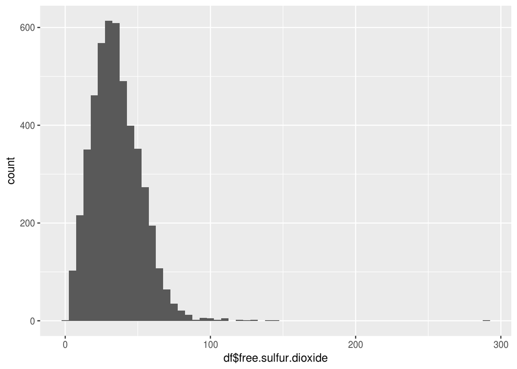

```
##    Min. 1st Qu.  Median    Mean 3rd Qu.    Max.
##    2.00   23.00   34.00   35.31   46.00  289.00
```

The amount of free sulfur dioxide present ranges from 2 milligrams per cubic decimetre to 46 milligrams per cubic decimetre for 75 % of the samples with a median of 34 milligrams per cubic decimetre.

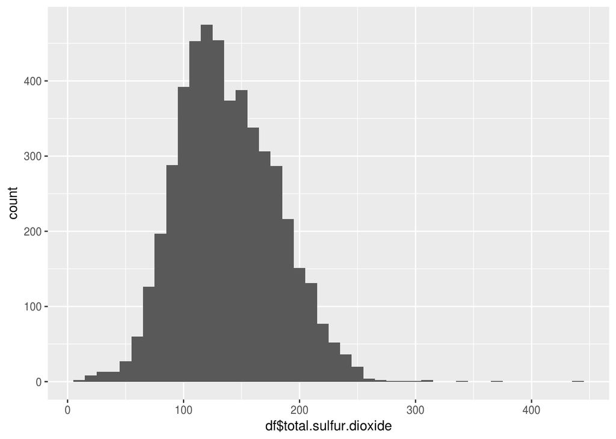

```
##    Min. 1st Qu.  Median    Mean 3rd Qu.    Max.
##     9.0   108.0   134.0   138.4   167.0   440.0
```

The total amount of sulfur dioxide has a much wider range with the amount varying between 9 milligrams per cubic decimetre and 167 milligrams per cubic decimetre for 75 % of the samples with a median of 134 milligrams per cubic decimetre.

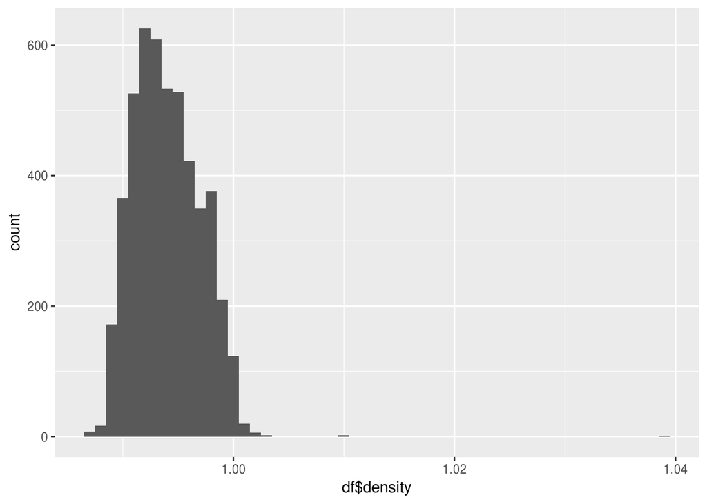

```
##    Min. 1st Qu.  Median    Mean 3rd Qu.    Max.
##  0.9871  0.9917  0.9937  0.9940  0.9961  1.0390
```

The density for most of the wine samples falls in a rather narrow range just very slightly below 1 (that is, the density of water). This is understandable given that wine contains ethanol, which has a density of only 0.789.

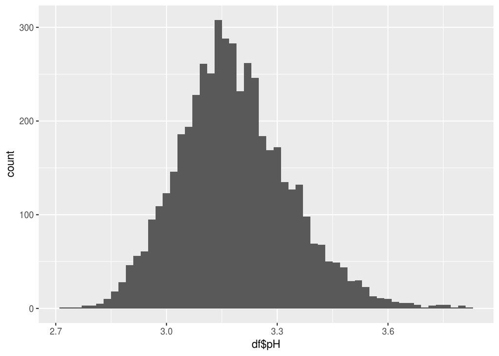

```
##    Min. 1st Qu.  Median    Mean 3rd Qu.    Max.
##   2.720   3.090   3.180   3.188   3.280   3.820
```

For pH the range is also rather narrow one, varying from 2.72 to 3.28 for 75 % of the samples with a median of 3.18. Of course, since the pH scale is logarithmic, even these small differences can mean rather large and noticeable differences in the actual taste of the wine samples.

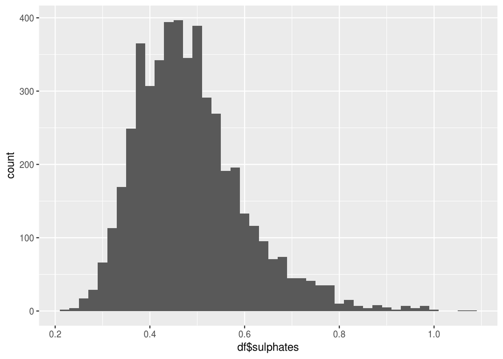

```
##    Min. 1st Qu.  Median    Mean 3rd Qu.    Max.
##  0.2200  0.4100  0.4700  0.4898  0.5500  1.0800
```

Sulphates present in the samples range from 0.22 grams per cubic decimetre to 0.55 grams per cubic decimetre for 75 % of the samples with a median of 0.47 grams per cubic decimetre.

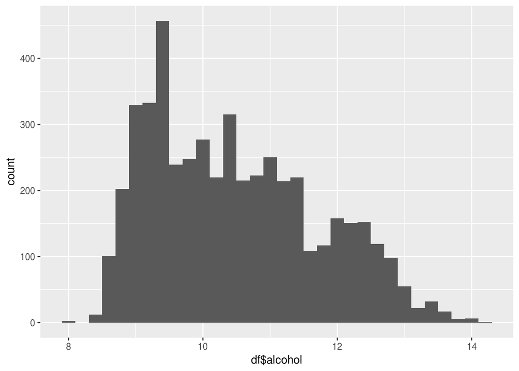

```
##    Min. 1st Qu.  Median    Mean 3rd Qu.    Max.
##    8.00    9.50   10.40   10.51   11.40   14.20
```

The proportion of alcohol (ethanol, to be precise) in the samples ranges from 8 % to 14.2 % of the sample volume with a median of 10.4 %. The histogram for the variable shows that the distribution is somewhat right-tailed one, with a particularly large number of samples being in the 9.0 - 9.5 % alcohol volume range. On the other hand, the alcohol content distribution doesn’t have any real outliers, unlike the previous variables considered.

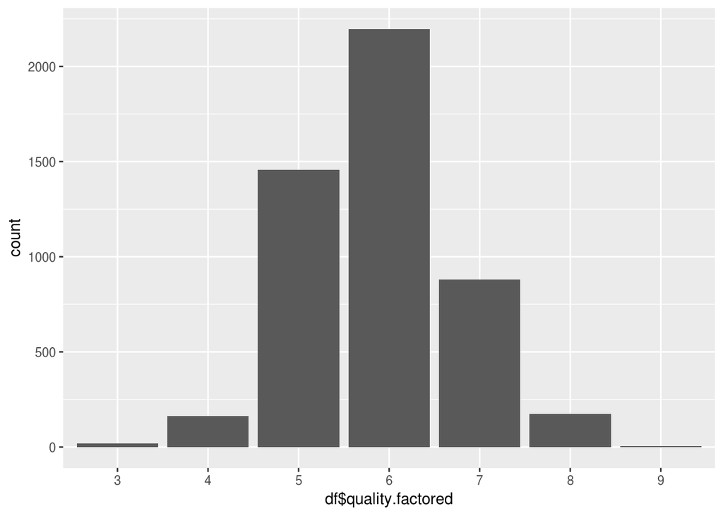

```
##    3    4    5    6    7    8    9
##   20  163 1457 2198  880  175    5
```

Finally, there is the histogram and value summary for the wine quality samples as judged by at least three wine-tasting experts. While the full rating scale for quality is from 0 to 10, in the current dataset no sample gets a rating lower than 3 or higher than 9. Majority of the ratings are concentrated in the 5-7 middle value range.

# Univariate Analysis

As the histograms above show, most of the chemical/physical qualities of the wine samples tend to have a roughly normal distribution across the different samples. However, the plots also show that pretty much all of the distributions have more or less right-skewing tails. Related to this, it is also worth noting that as the numerical summaries clearly show, the maximum values for almost all of the above distributions are markedly larger than the upper bound of 0.75 quantile, which indicates that there are outliers present in the distributions.

There are also two variables which have distributions that don’t really conform to the properties of a normal distribution. As noted before, the amount of residual sugar in the samples is heavily concentrated in the lowest levels of the value range. Another variable that doesn’t quite fit the normal distribution mold is the alcohol content of the samples which is also somewhat concentrated on the low end of the value range, though not as dramatically as the residual sugar levels. I will apply some additional attention on these two variables in the next section to make some more sense of these distributions.

The data seems tidy enough as it is, so any transformations or other operations to tidy it up don’t seem necessary. However, I did make a factor version of the expert rating variable to be used alongside the original variable in those situations and examinations where it is necessary to use a factor-scale variable.

# Bivariate Plots Section

Based on the considerations lined out above, the main question of interest concerning the dataset is whether an association can be found between the chemical/physical qualities of a wine sample and the rating given to it by the wine-tasting experts. To investigate that question, I start by making boxplots of all the said qualities grouped by the expert ratings as well as calculating Pearson’s correlation coefficients for these qualities in relation to the ratings.

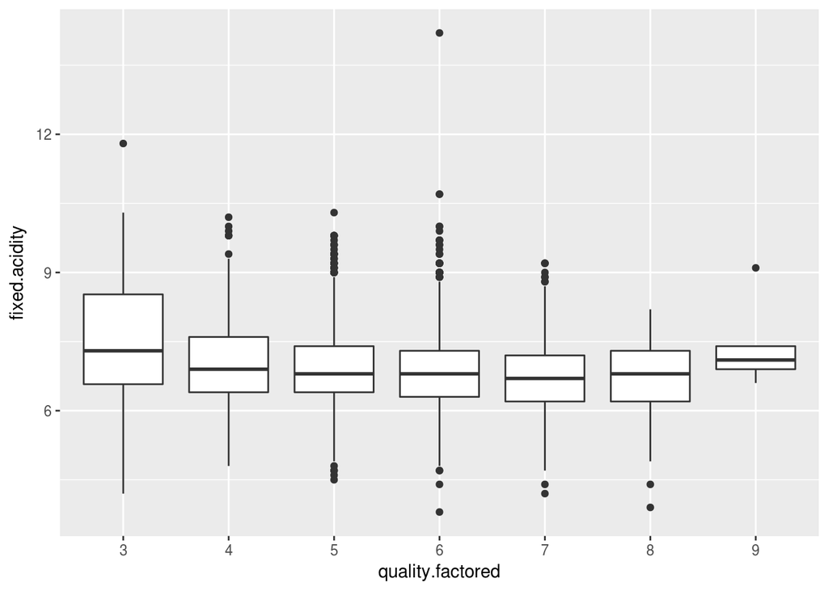

```
##
##  Pearson's product-moment correlation
##
## data:  df$quality and df$fixed.acidity
## t = -8.005, df = 4896, p-value = 1.48e-15
## alternative hypothesis: true correlation is not equal to 0
## 95 percent confidence interval:
##  -0.14121974 -0.08592991
## sample estimates:
##        cor
## -0.1136628
```

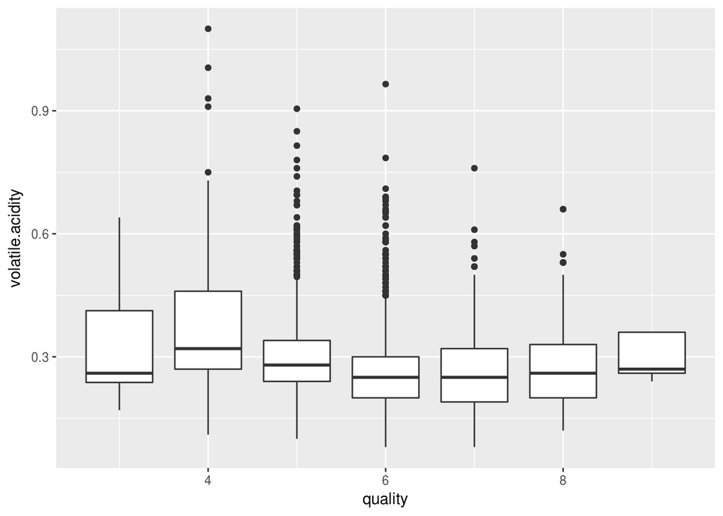

```
##
##  Pearson's product-moment correlation
##
## data:  df$quality and df$volatile.acidity
## t = -13.891, df = 4896, p-value < 2.2e-16
## alternative hypothesis: true correlation is not equal to 0
## 95 percent confidence interval:
##  -0.2215214 -0.1676307
## sample estimates:
##       cor
## -0.194723
```

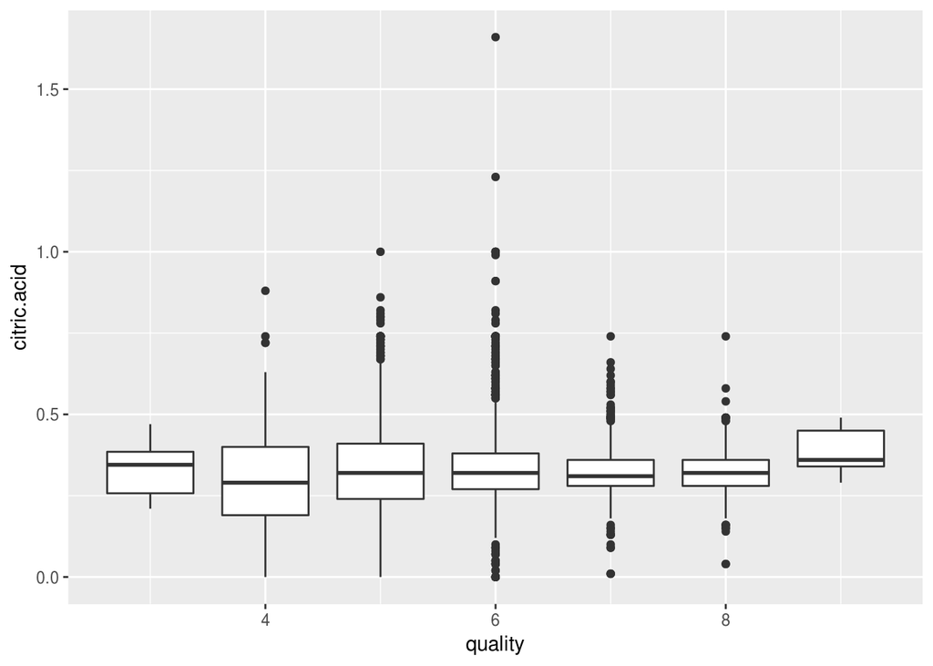

```
##
##  Pearson's product-moment correlation
##
## data:  df$quality and df$citric.acid
## t = -0.6444, df = 4896, p-value = 0.5193
## alternative hypothesis: true correlation is not equal to 0
## 95 percent confidence interval:
##  -0.03720595  0.01880221
## sample estimates:
##          cor
## -0.009209091
```

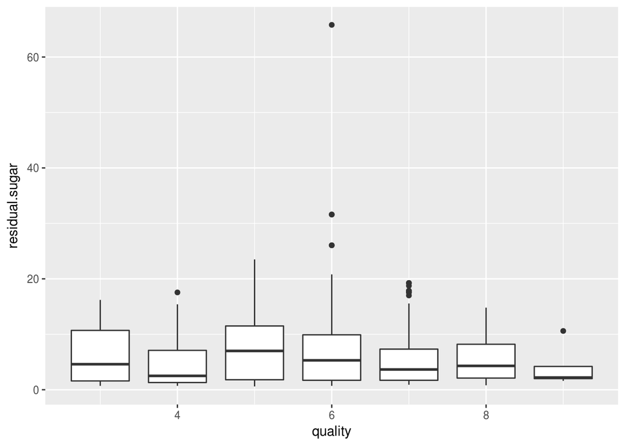

```
##
##  Pearson's product-moment correlation
##
## data:  df$quality and df$residual.sugar
## t = -6.8603, df = 4896, p-value = 7.724e-12
## alternative hypothesis: true correlation is not equal to 0
## 95 percent confidence interval:
##  -0.12524103 -0.06976101
## sample estimates:
##         cor
## -0.09757683
```

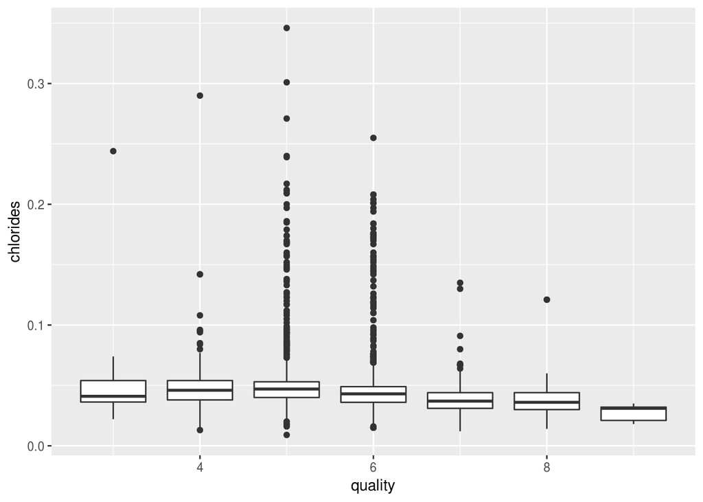

```
##
##  Pearson's product-moment correlation
##
## data:  df$quality and df$chlorides
## t = -15.024, df = 4896, p-value < 2.2e-16
## alternative hypothesis: true correlation is not equal to 0
## 95 percent confidence interval:
##  -0.2365501 -0.1830039
## sample estimates:
##        cor
## -0.2099344
```

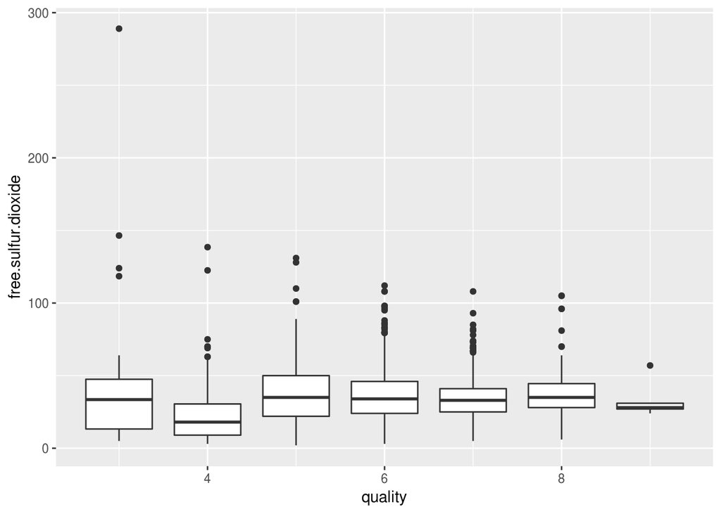

```
##
##  Pearson's product-moment correlation
##
## data:  df$quality and df$free.sulfur.dioxide
## t = 0.57085, df = 4896, p-value = 0.5681
## alternative hypothesis: true correlation is not equal to 0
## 95 percent confidence interval:
##  -0.01985292  0.03615626
## sample estimates:
##         cor
## 0.008158067
```

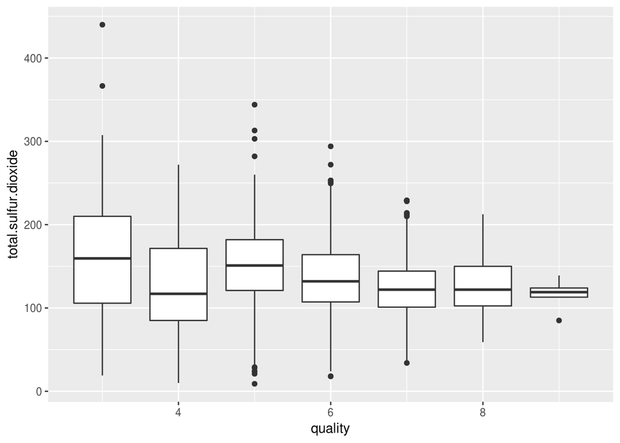

```
##
##  Pearson's product-moment correlation
##
## data:  df$quality and df$total.sulfur.dioxide
## t = -12.418, df = 4896, p-value < 2.2e-16
## alternative hypothesis: true correlation is not equal to 0
## 95 percent confidence interval:
##  -0.2017563 -0.1474524
## sample estimates:
##        cor
## -0.1747372
```

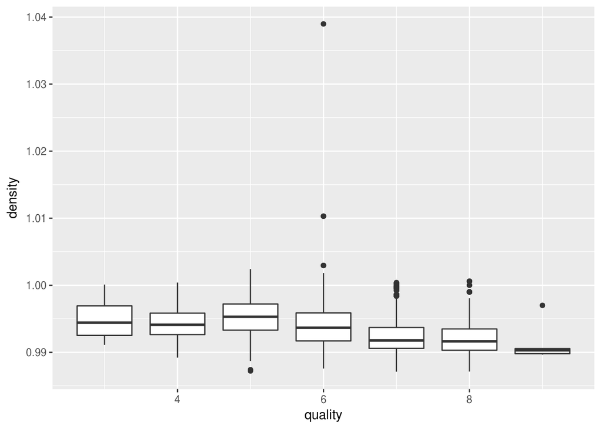

```
##
##  Pearson's product-moment correlation
##
## data:  df$quality and df$density
## t = -22.581, df = 4896, p-value < 2.2e-16
## alternative hypothesis: true correlation is not equal to 0
## 95 percent confidence interval:
##  -0.3322718 -0.2815385
## sample estimates:
##        cor
## -0.3071233
```

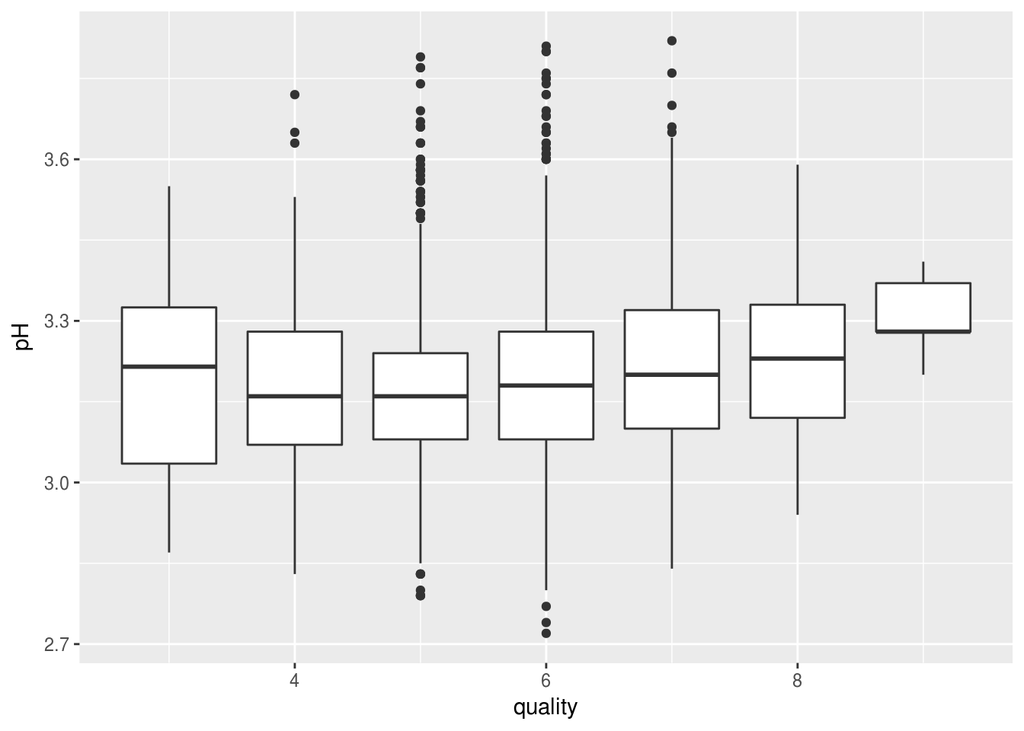

```
##
##  Pearson's product-moment correlation
##
## data:  df$quality and df$pH
## t = 6.9917, df = 4896, p-value = 3.081e-12
## alternative hypothesis: true correlation is not equal to 0
## 95 percent confidence interval:
##  0.07162022 0.12707983
## sample estimates:
##        cor
## 0.09942725
```

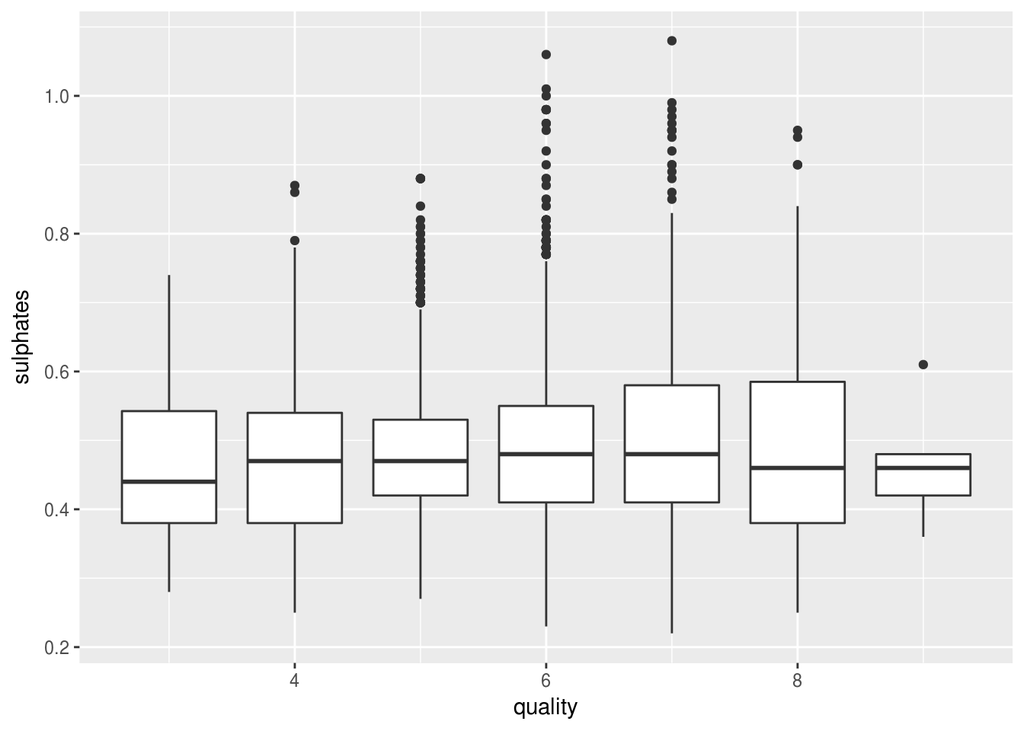

```
##
##  Pearson's product-moment correlation
##
## data:  df$quality and df$sulphates
## t = 3.7613, df = 4896, p-value = 0.000171
## alternative hypothesis: true correlation is not equal to 0
## 95 percent confidence interval:
##  0.02571007 0.08156172
## sample estimates:
##        cor
## 0.05367788
```

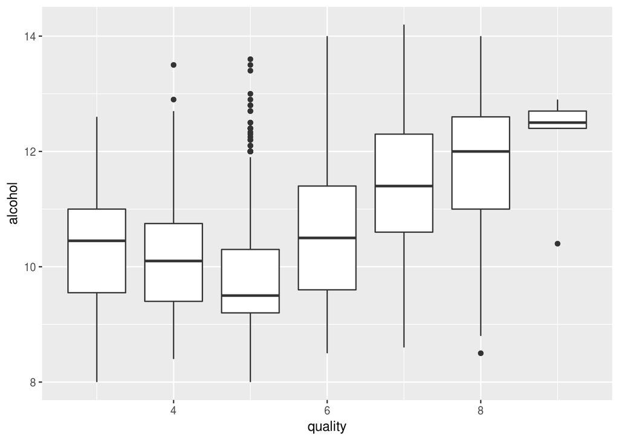

```
##
##  Pearson's product-moment correlation
##
## data:  df$quality and df$alcohol
## t = 33.858, df = 4896, p-value < 2.2e-16
## alternative hypothesis: true correlation is not equal to 0
## 95 percent confidence interval:
##  0.4126015 0.4579941
## sample estimates:
##       cor
## 0.4355747
```

I am also examining if there are observeable associations between some of the other variables of the dataset as well. I am first taking a look at the relationship between the alcohol content of a wine sample and the amount of residual sugar present in it. As the sugar of the grapes tranforms into ethanol during the fermentation process of the wine, my initial assumption would be that those wine samples with a higher alcohol content would have less residual sugar present in them.

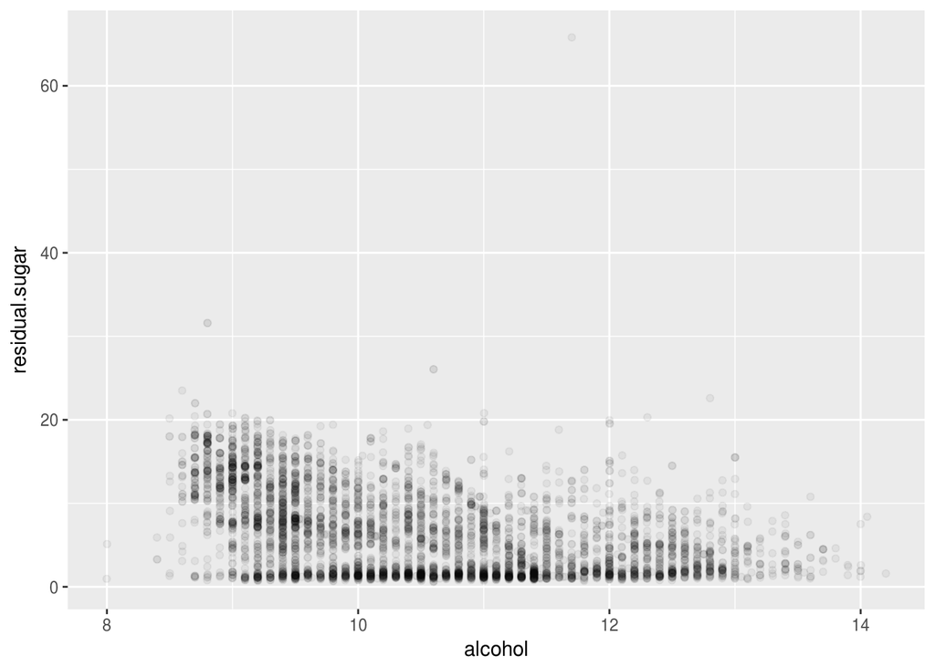

```
##
##  Pearson's product-moment correlation
##
## data:  df$alcohol and df$residual.sugar
## t = -35.321, df = 4896, p-value < 2.2e-16
## alternative hypothesis: true correlation is not equal to 0
## 95 percent confidence interval:
##  -0.4726723 -0.4280267
## sample estimates:
##        cor
## -0.4506312
```

I am also interested to see if those samples with a higher alcohol content have a lower density than those with less alcohol in them, as the density of ethanol is less than that of water.

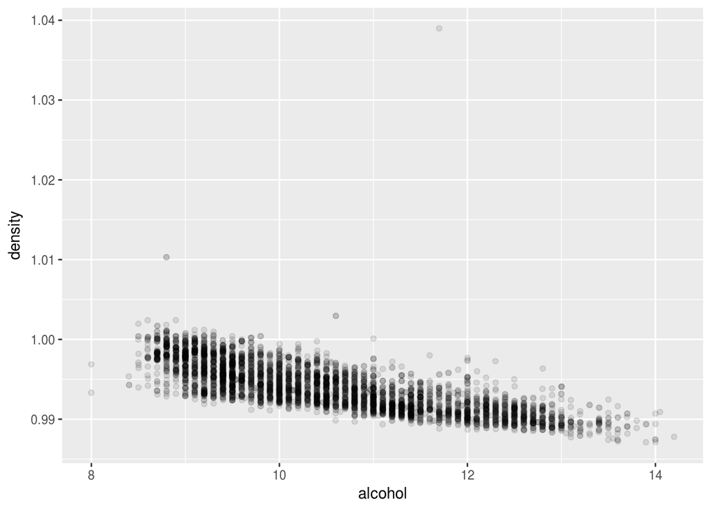

```
##
##  Pearson's product-moment correlation
##
## data:  df$alcohol and df$density
## t = -87.255, df = 4896, p-value < 2.2e-16
## alternative hypothesis: true correlation is not equal to 0
## 95 percent confidence interval:
##  -0.7908646 -0.7689315
## sample estimates:
##        cor
## -0.7801376
```

# Bivariate Analysis

For most of the chemical/physical qualities of the wine samples there doesn’t seem to be any particularly noteworthy variation when they are examined across the expert ratings. The value ranges for most of the variables are rather narrow to begin with, and especially when looking at the median values, the variation doesn’t seem to exhibit discernible patterns for most of the variables. Also, most of the coefficients calculated for correlations between the quality ratings and other variables are not particularly strong.

However, a few of the chemical/physical qualities of the samples exhibit an association with the expert ratings that are clear and consistent enough to warrant further examination. In terms of the correlation coefficients, the strongest associations that the expert ratings have are with alcohol content (r = 0.44), density (r = -0.31), chlorides (r = -0.21), volatile acidity (r = -0.19), and total amount of sulfur dioxide (r = -0.17).

When looking at the boxplots of these variables by the levels of expert ratings, they mostly show similar relationships and trends as indicated by the correlation coefficients. However, it is worth noting that the boxplots for chloride and volatile acidity levels show numerous instances of outliers in the distributions of these variables. This factor calls for prudence in further analyses concerning these two variables.

With regards to the density of the samples, the scatter plot of sample density vs. alcohol content which ends the previous section shows a clear (and linear) relationship between these two variables. This is also affirmed by the strong correlation coefficient (r = -0.78) of the variables. Thus, the density of the samples can be considered to be mostly a function of their alcohol content and should be dropped from further investigations as a superfluous and possibly confounding variable.

However, given that the alcohol content of the samples affects their density in observeable amounts, the couple of outliers that have a density above that of water invite some interesting speculation. Could it be that the samples in question have also some foreign substances present in them that increase their density to a marked degree?

Finally, the plot of residual sugar vs. alcohol content presents a more complex relationship. While in general terms the samples with higher alcohol levels tend to have lower amounts of residual sugar, there are also samples with low levels of both alcohol and residual sugar. So while there are wine samples where the fermentation process has not processed all of the sugar into ethanol, there are probably also grape strains with lower levels of sugar to begin with - and thus also low levels of alcohol in the end product as well.

# Multivariate Plots Section

In the previous section four variables were identified which exhibited noteworthy relationships with the quality ratings of the samples: alcohol content, total amount of sulfur dioxide, volatile acidity and chloride levels of the samples. Next, I am making several scatter plots to see if the pairwise plotting of these chemical/physical qualities grouped by the expert rating levels shows any clear trivariate relationships between these variables.

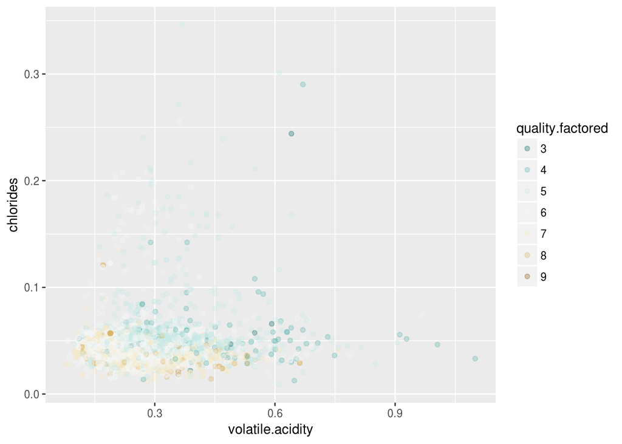

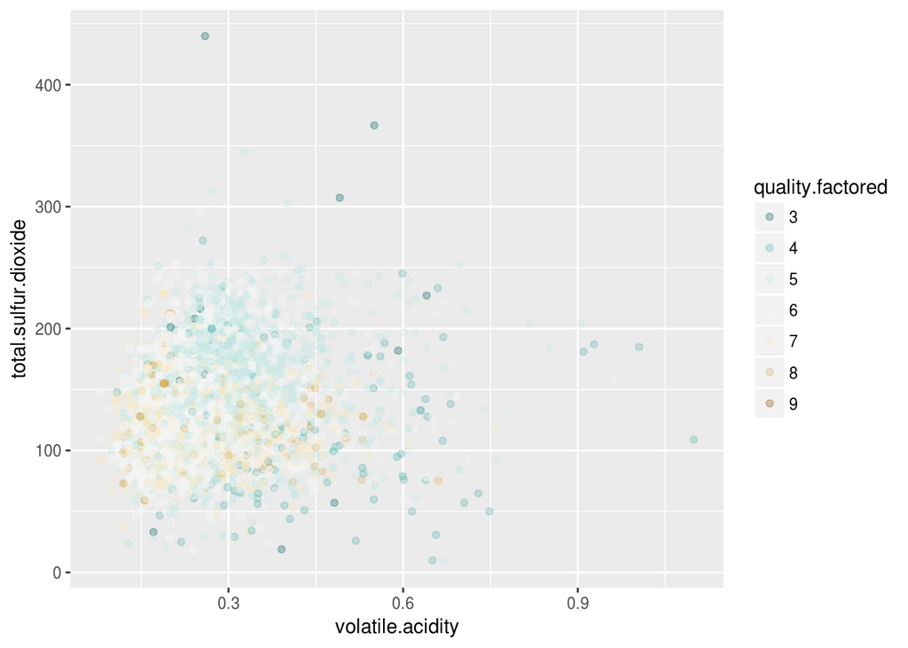

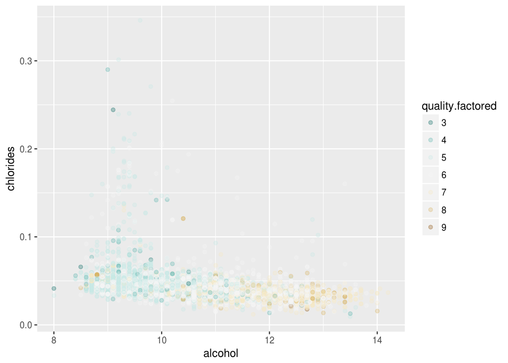

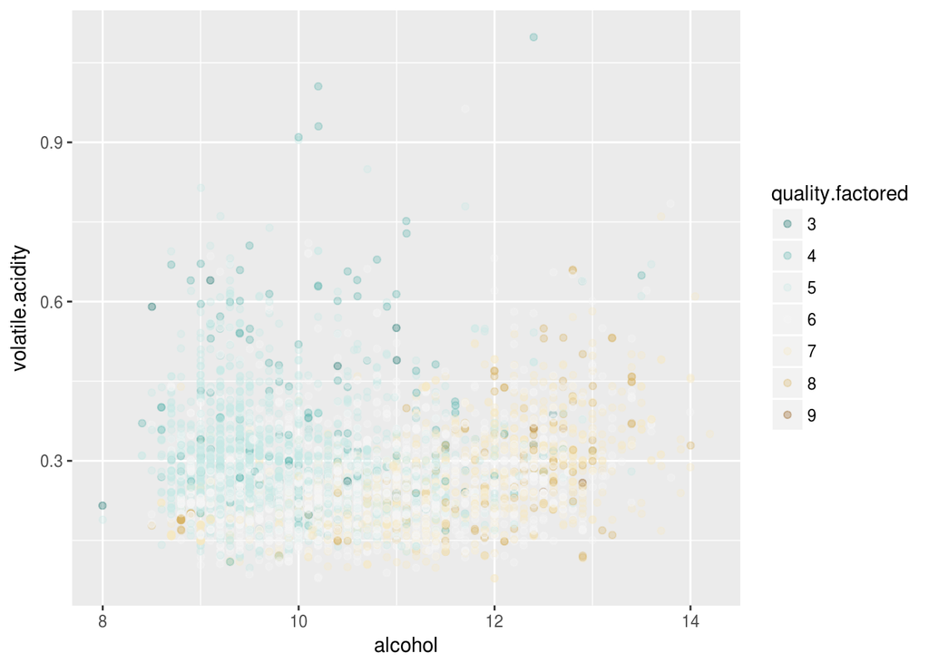

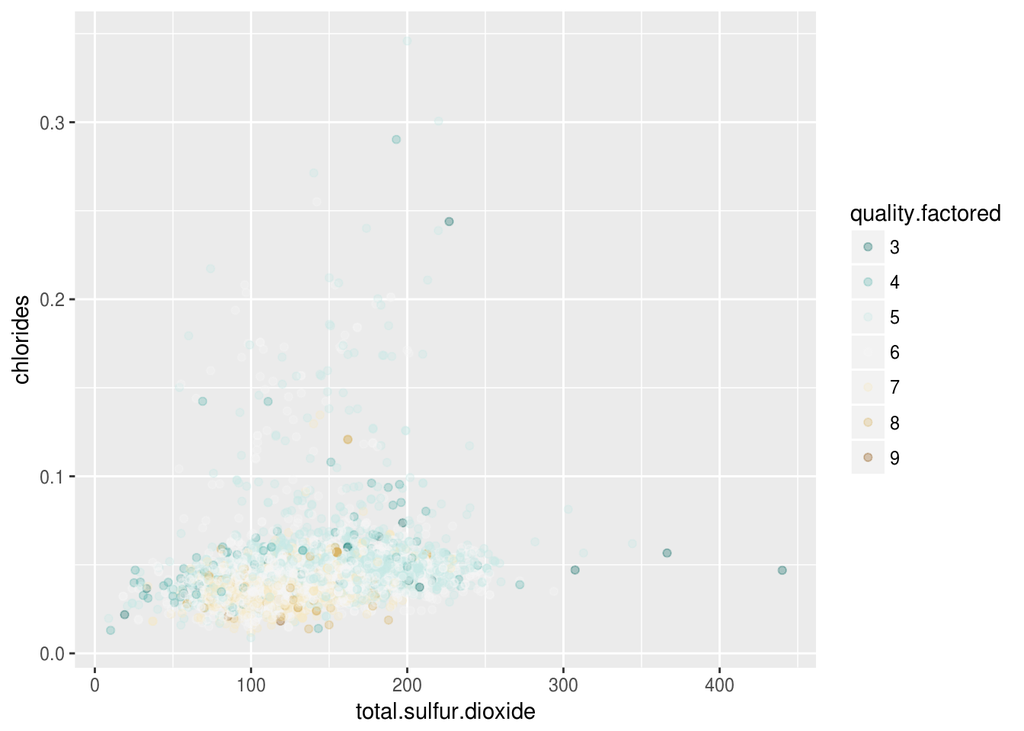

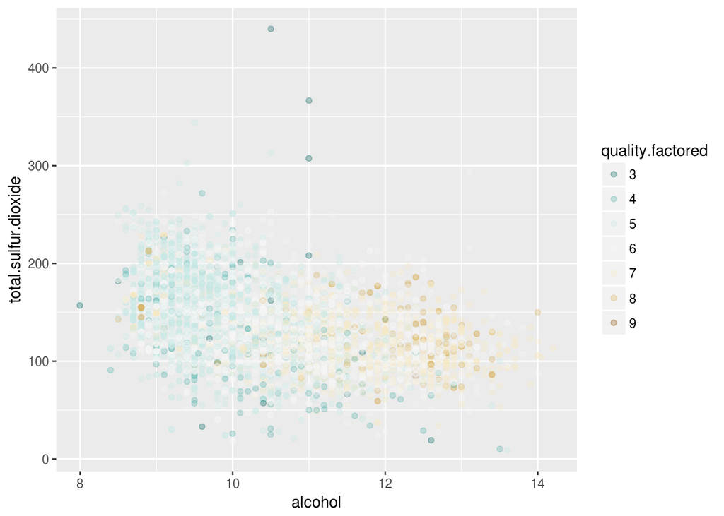